# Project 1 - Early Detection of Diabetes

2024-03-20

## Diabetes

- Diabetes is a chronic (long-lasting) health condition that affects how your body turns food into energy.
- Your body breaks down most of the food you eat into sugar (glucose) and releases it into your bloodstream. When your blood sugar goes up, it signals your pancreas to release insulin. Insulin acts like a key to let the blood sugar into your body’s cells for use as energy.
- There isn’t a cure yet for diabetes, but losing weight, eating healthy food, and being active can really help.

## Pre-Diabetes

- In the United States, about 98 million adults—more than 1 in 3—have prediabetes.
- More than 8 in 10 of them don’t know they have it.
- [Source](https://www.cdc.gov/diabetes/basics/diabetes.html)

## Diabetes Classification Model

We set out to investigate applications of diabetes research. We aimed to develop a classification model that can predict early-stage diabetes based on several medical predictor variables.

## How the Data looks like

```
##   Age Gender Polyuria Polydipsia sudden.weight.loss weakness Polyphagia
## 1  40   Male       No        Yes                 No      Yes         No
## 2  58   Male       No         No                 No      Yes         No
## 3  41   Male      Yes         No                 No      Yes        Yes
## 4  45   Male       No         No                Yes      Yes        Yes
## 5  60   Male      Yes        Yes                Yes      Yes        Yes
## 6  55   Male      Yes        Yes                 No      Yes        Yes
##   Genital.thrush visual.blurring Itching Irritability delayed.healing
## 1             No              No     Yes           No             Yes
## 2             No             Yes      No           No              No
## 3             No              No     Yes           No             Yes
## 4            Yes              No     Yes           No             Yes
## 5             No             Yes     Yes          Yes             Yes
## 6             No             Yes     Yes           No             Yes
##   partial.paresis muscle.stiffness Alopecia Obesity    class
## 1              No              Yes      Yes     Yes Positive
## 2             Yes               No      Yes      No Positive
## 3              No              Yes      Yes      No Positive
## 4              No               No       No      No Positive
## 5             Yes              Yes      Yes     Yes Positive
## 6              No              Yes      Yes     Yes Positive
```

## Dataset

```
##       Age           Gender            Polyuria          Polydipsia
##  Min.   :16.00   Length:520         Length:520         Length:520
##  1st Qu.:39.00   Class :character   Class :character   Class :character
##  Median :47.50   Mode  :character   Mode  :character   Mode  :character
##  Mean   :48.03
##  3rd Qu.:57.00
##  Max.   :90.00
##  sudden.weight.loss   weakness          Polyphagia        Genital.thrush
##  Length:520         Length:520         Length:520         Length:520
##  Class :character   Class :character   Class :character   Class :character
##  Mode  :character   Mode  :character   Mode  :character   Mode  :character
##
##
##
##  visual.blurring      Itching          Irritability       delayed.healing
##  Length:520         Length:520         Length:520         Length:520
##  Class :character   Class :character   Class :character   Class :character
##  Mode  :character   Mode  :character   Mode  :character   Mode  :character
##
##
##
##  partial.paresis    muscle.stiffness     Alopecia           Obesity
##  Length:520         Length:520         Length:520         Length:520
##  Class :character   Class :character   Class :character   Class :character
##  Mode  :character   Mode  :character   Mode  :character   Mode  :character
##
##
##
##     class
##  Length:520
##  Class :character
##  Mode  :character
##
##
##
```

## Class Distribution

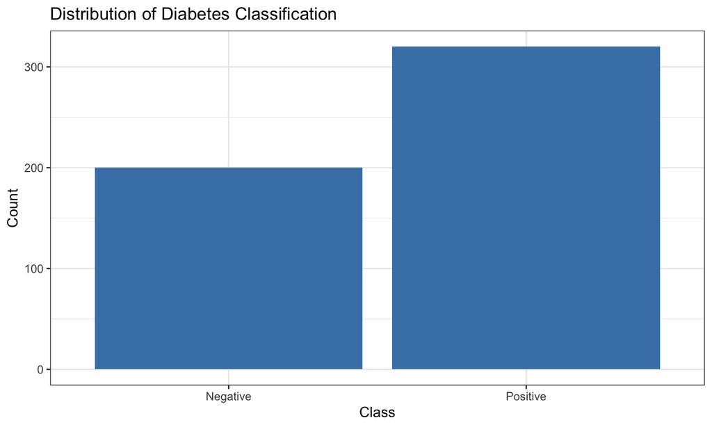

## Numerical Variables Distribution

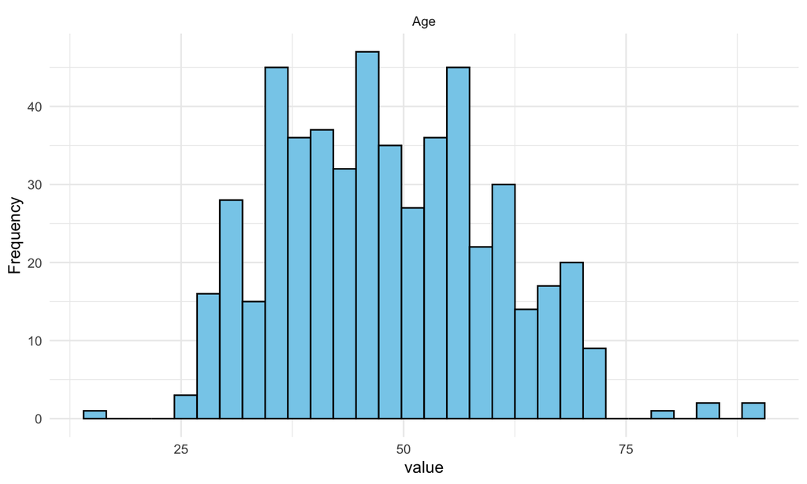

## Relationship Between Attributes and Class

Here we discover higher proportions within the positive diabetes criteria, for the attributes: gender, polydispia, polyphagia, sudden weight loss, partial paresis, and general weakness. This finding is to be expected since all of the variables listed thus far and known to have some relationship with a positive diagnosis. However, the proportion within the alopecia category was suprising. Since both type 1 and 2 diabetes often induces hair loss and makes individuals prone to developing alopecia conditions.

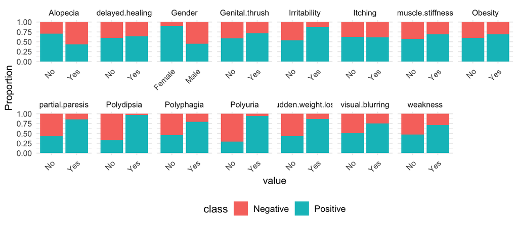

## Boxplot Examining Age and Class

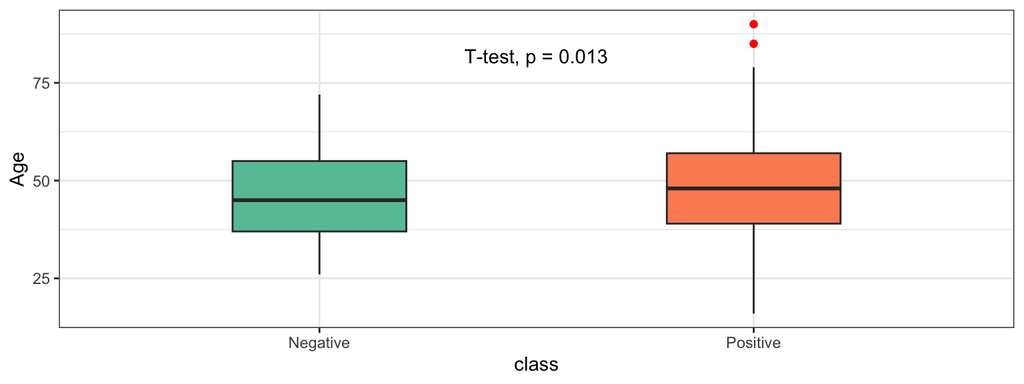

Based on the observations of the grouped boxplots and the results of the t-test, we found that age was significant for the predicted categories. Specifically, there is a difference in the medians of the negative and positive age groups, with the positive group having a larger median than the negative group. This suggests that age plays an important role in differentiating categories.

## Significance Testing

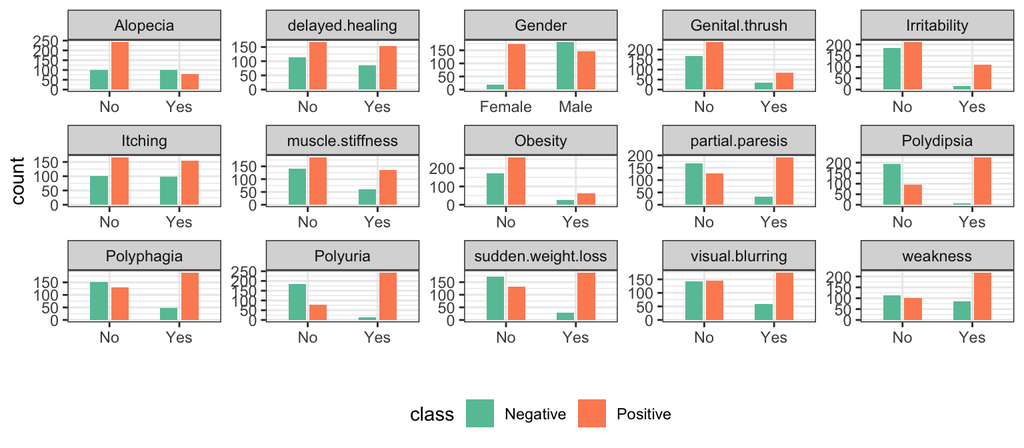

According to the grouped bar chart, we found that the variables “delayed healing”, “Genital thrush”, “Obesity” and “ltching” have no significant difference in the proportion of distribution in different categories. This suggests that these four variables may not play an important role in prediction.

## Model Building and Evaluation

We selected two models for our analysis: Support Vector Machine (SVM) and Neural Network. These models were chosen due to their ability to handle complex non-linear relationships between features.

### SVM

We used SVM model, also known as support vector machine model. SVM models are supervised machine learning models which can be used to solve a multitude of problems by performing data transformations. It is our hope that this model will effectively make a prediction model.

## 1

```
## Training set accuracy:  0.9769452
```

```
## Test set accuracy:  0.9537572
```

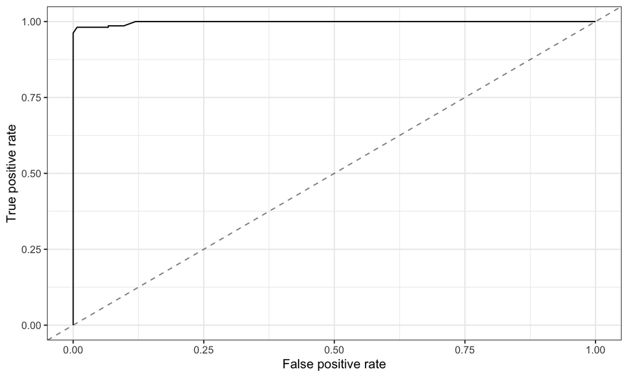

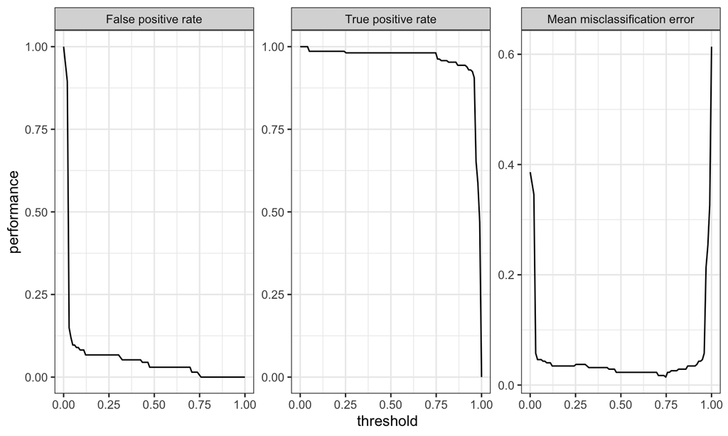

According to the above two figures, the training set’s AUC for the support vector machine with its default parameters is essentially close to 1, and the threshold of 0.5 was chosen appropriately. At this point, the training set’s accuracy is 0.9769452, while the test set’s accuracy rate is 0.9537572.

## Here begin resampling the data and setting discrete parameters.

```
## Tune result:
## Op. pars: cost=0.422; gamma=0.1
## acc.test.mean=0.9653782,mmce.test.mean=0.0346218
```

The ideal settings for the 10-fold cross-validation are {cost=0.422; gamma=0.1}, and the associated average accuracy rate is 0.9653782.

## 3

The accuracy rate on the test set is 0.9595376, while the accuracy rate on the training set is 0.9711816, as can be observed from the above findings; the performance of the optimized SVM is marginally better on the test set. This is because there is less overfitting on the training set, which increases accuracy and generalization capacity on the test set.

```
## Training set accuracy:  0.9711816
```

```
## Test set accuracy:  0.9595376
```

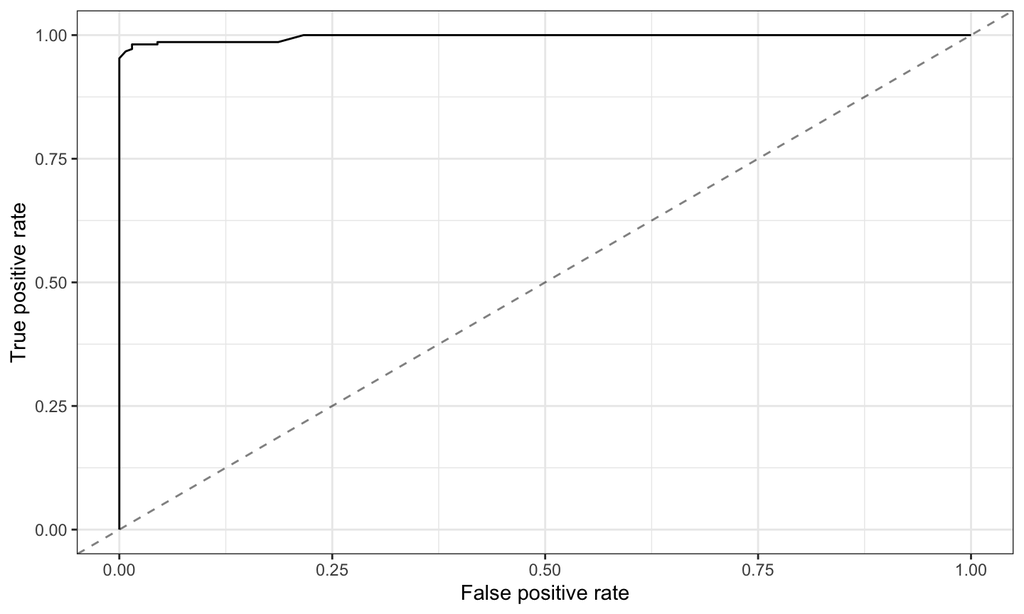

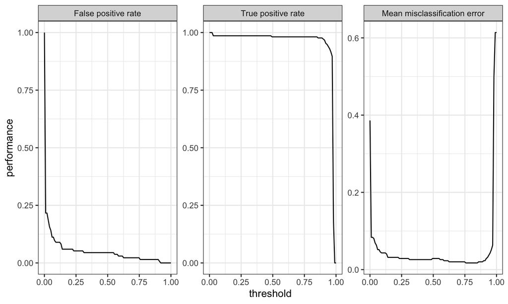

### Neural Network

Neural Networks are powerful computational models that mimic the way neurons in the human brain operate, making them particularly effective for capturing complex patterns. Here we attempt to build a second model which may be more effective than the SVM model.

```
## Training set accuracy:  0.8962536
```

```
## Test set accuracy:  0.8843931
```

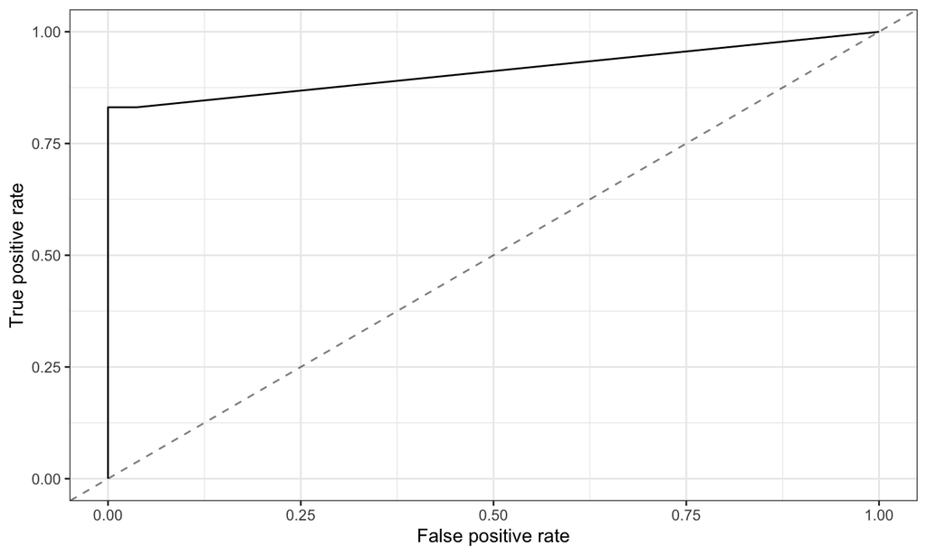

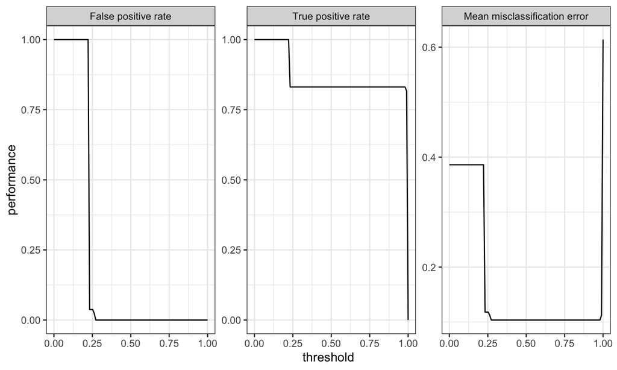

The aforementioned data demonstrate how much poorer the neural network’s default performance is than the support vector machine’s. As of right now, the test set’s accuracy rate is 0.8843931, while the training set’s accuracy rate is 0.8962536.

## 1

```
## Tune result:
## Op. pars: size=10; decay=0.001; maxit=10000
## acc.test.mean=0.9684874,mmce.test.mean=0.0315126
```

For the neural network, I chose to optimize three parameters. Under 10-fold cross-validation, the optimal parameter combination is `size=10; decay=0.001; maxit=10000`, and the corresponding average accuracy rate is 0.9684874.

## 2

```
## Training set accuracy:  1
```

```
## Test set accuracy:  0.9248555
```

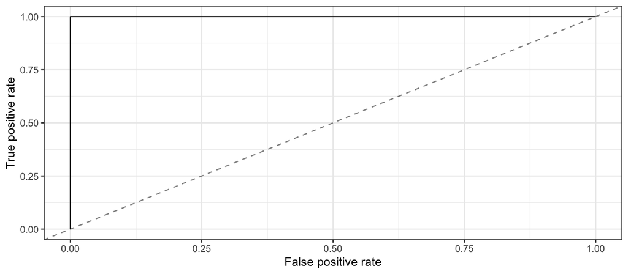

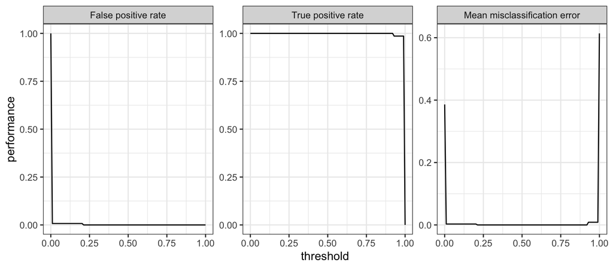

The optimized neural network performs better than the neural network with default settings (size = 3), with an accuracy rate of 1 on the training set and 0.9248555 on the test set.

## Model Evalutaions

Here we will be begin our analysis on the comparison of both models to find the most effective one.

```
##   task.id   learner.id acc.test.mean mmce.test.mean ber.test.mean
## 1  svm-nn  classif.svm     0.9481513     0.05184874    0.06165036
## 2  svm-nn classif.nnet     0.9483193     0.05168067    0.05989528
```

## plot

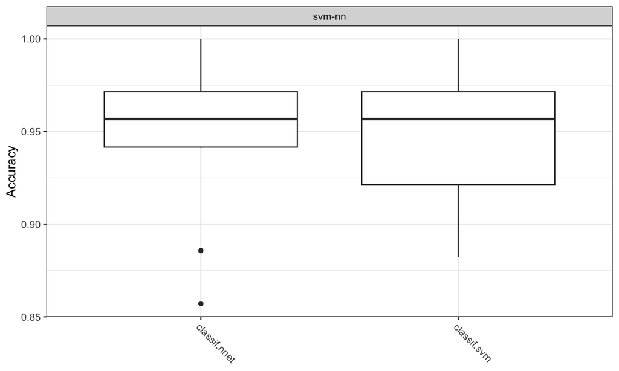

## outcome

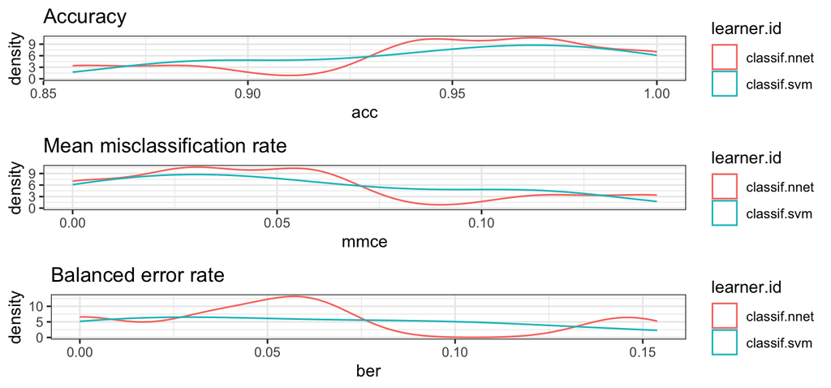

Based on the outcomes of 10-fold cross-validation, it can be inferred that the two models’ performance on the training set is almost identical. The neural network performs marginally better, although it frequently performs worse on the test set because to its propensity for overfitting.